# To what extent do food deserts exist in various cities in the state of Utah?

Kishan Thambu and Anisa Habib

5/3/2022

## Introduction

For several decades, health officials have encouraged people to eat more nutritious foods like fruits and vegetables and avoid junk or processed foods like chips and fast food in order to maintain a healthy diet and prevent several diseases and other health issues. However, for many families in the United States, access to these healthy foods are hard to even access. This lack of access to healthy food resources is just one aspect of what is known as a “food desert”. A food desert is an area that has limited access to affordable and nutritious food. These areas tend to be inhabited by low-income residents with reduced mobility, which makes them less attractive markets for large supermarket chains, causing the location to lack suppliers of fresh foods. Instead, processed food and food high in sugar and fats, which are known contributors to the proliferation of obesity in the US, are more readily available for consumption. In contrast, an area with higher access to supermarkets or vegetable shops with fresh foods is called a food oasis. The designation considers the type and the quality of food available to the population, in addition to the accessibility of the food through the size and the proximity of the food stores. In 2010, the United States Department of Agriculture reported that 23.5 million people in the US live in these “food deserts,” low-income census tracts that are more than 1 mile (1609.34 meters) from a supermarket in urban or suburban areas and more than 10 miles (16093.4 meters) from a supermarket in rural areas. In this study, we aim to explore *to what extent food deserts exist in various cities throughout the state of Utah*.

## Data Sources

To answer this projects research question, we used store distance and store type data from Google Maps. Furthermore, we will also be interpreting population and median household income from the US Census Bureau. More specifically, our data set includes variables for city, population, city type (urban or rural), store, store type, latitude and longitude, and median household income. The latitude and longitude points will be used to calculate distance between other stores by city.

## Data Collection and Methodology

The methodology for the collection of data in this study was built around the availability of store and census data and the research question.

Including the above steps, we followed the following methodology to gain a better understanding of the data and compute relevant analyses:

1. Operationalize the research question into one that is actually quantifiable.
   - We need a question about a population parameter that we can estimate with a sample statistic.
2. Identify an appropriate sampling strategy.
   - Collect data on 5 random stores from 10 random cities (5 urban, 5 rural)
3. Identify the appropriate probability distribution.
   - The central limit theorem (CLT): under broad conditions the sampling distribution of the mean converges to normal.
4. Compute a margin of error so that there is a (1 - α) probability of getting a sample statistic within that margin of the population parameter.
   - For the relevant sample statistic, we plan to take a **95%** two-sided confidence interval.
5. Compute the relevant sample statistics.
   - Compute average distance between stores using *Geosphere* R package
   - Compute average store type
6. Create the relevant summary figures.
   - Create a bar plot for each variable with bars to represent each city, and an indication of whether the city is urban or rural.
   - Create histograms for relevant variables.
7. Arithmetic the margin of error around the sample statistic to find likely locations of the population parameter.
8. Provide a context-appropriate interpretation of the confidence and bounds.

We decided to choose a confidence level of 95%. This confidence is “moderately” or “pretty” strong and chosen with consideration of the limited number of stations used for sample data collection.

## Initial Data Summaries

To start analyzing the collected data, the csv files were read into RStudio.

```r
# read in data
healthfooddata <- read.csv("healthfooddata.csv")
# filter data
slc_data <- healthfooddata[which(healthfooddata$city == 'Salt Lake City'),]
provo_data <- healthfooddata[which(healthfooddata$city == 'Provo'),]
sj_data <- healthfooddata[which(healthfooddata$city == 'South Jordan'),]
orem_data <- healthfooddata[which(healthfooddata$city == 'Orem'),]
logan_data <- healthfooddata[which(healthfooddata$city == 'Logan'),]
wellington_data <- healthfooddata[which(healthfooddata$city == 'Wellington'),]
morgan_data <- healthfooddata[which(healthfooddata$city == 'Morgan'),]
farmington_data <- healthfooddata[which(healthfooddata$city == 'Farmington'),]
roosevelt_data <- healthfooddata[which(healthfooddata$city == 'Roosevelt'),]
woodscross_data <- healthfooddata[which(healthfooddata$city == 'Woods Cross'),]
```

Once all the data was read in, preliminary summary statistics were generated by the R code below:

```r
# data summaries
summary(slc_data)
```

```
##      city              county            population      city.type
##  Length:5           Length:5           Min.   :200963   Length:5
##  Class :character   Class :character   1st Qu.:200963   Class :character
##  Mode  :character   Mode  :character   Median :200963   Mode  :character
##                                        Mean   :200963
##                                        3rd Qu.:200963
##                                        Max.   :200963
##     store            store.type           latitude       longitude
##  Length:5           Length:5           Min.   :40.70   Min.   :-111.9
##  Class :character   Class :character   1st Qu.:40.72   1st Qu.:-111.9
##  Mode  :character   Mode  :character   Median :40.73   Median :-111.9
##                                        Mean   :40.73   Mean   :-111.9
##                                        3rd Qu.:40.73   3rd Qu.:-111.9
##                                        Max.   :40.76   Max.   :-111.9
##  median.household.income
##  Min.   :63156
##  1st Qu.:63156
##  Median :63156
##  Mean   :63156
##  3rd Qu.:63156
##  Max.   :63156
```

```r
summary(provo_data)
```

```
##      city              county            population      city.type
##  Length:5           Length:5           Min.   :116582   Length:5
##  Class :character   Class :character   1st Qu.:116582   Class :character
##  Mode  :character   Mode  :character   Median :116582   Mode  :character
##                                        Mean   :116582
##                                        3rd Qu.:116582
##                                        Max.   :116582
##     store            store.type           latitude       longitude
##  Length:5           Length:5           Min.   :40.22   Min.   :-111.7
##  Class :character   Class :character   1st Qu.:40.25   1st Qu.:-111.7
##  Mode  :character   Mode  :character   Median :40.26   Median :-111.7
##                                        Mean   :40.25   Mean   :-111.7
##                                        3rd Qu.:40.26   3rd Qu.:-111.7
##                                        Max.   :40.28   Max.   :-111.7
##  median.household.income
##  Min.   :50072
##  1st Qu.:50072
##  Median :50072
##  Mean   :50072
##  3rd Qu.:50072
##  Max.   :50072
```

```r
summary(sj_data)
```

```
##      city              county            population     city.type
##  Length:5           Length:5           Min.   :84881   Length:5
##  Class :character   Class :character   1st Qu.:84881   Class :character
##  Mode  :character   Mode  :character   Median :84881   Mode  :character
##                                        Mean   :84881
##                                        3rd Qu.:84881
##                                        Max.   :84881
##     store            store.type           latitude       longitude
##  Length:5           Length:5           Min.   :40.54   Min.   :-112.0
##  Class :character   Class :character   1st Qu.:40.54   1st Qu.:-112.0
##  Mode  :character   Mode  :character   Median :40.54   Median :-112.0
##                                        Mean   :40.55   Mean   :-112.0
##                                        3rd Qu.:40.56   3rd Qu.:-111.9
##                                        Max.   :40.57   Max.   :-111.9
##  median.household.income
##  Min.   :104597
##  1st Qu.:104597
##  Median :104597
##  Mean   :104597
##  3rd Qu.:104597
##  Max.   :104597
```

```r
summary(orem_data)
```

```
##      city              county            population     city.type
##  Length:5           Length:5           Min.   :99022   Length:5
##  Class :character   Class :character   1st Qu.:99022   Class :character
##  Mode  :character   Mode  :character   Median :99022   Mode  :character
##                                        Mean   :99022
##                                        3rd Qu.:99022
##                                        Max.   :99022
##     store            store.type           latitude       longitude
##  Length:5           Length:5           Min.   :40.28   Min.   :-111.7
##  Class :character   Class :character   1st Qu.:40.28   1st Qu.:-111.7
##  Mode  :character   Mode  :character   Median :40.30   Median :-111.7
##                                        Mean   :40.30   Mean   :-111.7
##                                        3rd Qu.:40.30   3rd Qu.:-111.7
##                                        Max.   :40.31   Max.   :-111.7
##  median.household.income
##  Min.   :65622
##  1st Qu.:65622
##  Median :65622
##  Mean   :65622
##  3rd Qu.:65622
##  Max.   :65622
```

```r
summary(logan_data)
```

```
##      city              county            population     city.type
##  Length:5           Length:5           Min.   :52166   Length:5
##  Class :character   Class :character   1st Qu.:52166   Class :character
##  Mode  :character   Mode  :character   Median :52166   Mode  :character
##                                        Mean   :52166
##                                        3rd Qu.:52166
##                                        Max.   :52166
##     store            store.type           latitude       longitude
##  Length:5           Length:5           Min.   :41.74   Min.   :-111.8
##  Class :character   Class :character   1st Qu.:41.75   1st Qu.:-111.8
##  Mode  :character   Mode  :character   Median :41.75   Median :-111.8
##                                        Mean   :41.77   Mean   :-111.8
##                                        3rd Qu.:41.76   3rd Qu.:-111.8
##                                        Max.   :41.83   Max.   :-111.8
##  median.household.income
##  Min.   :43056
##  1st Qu.:43056
##  Median :43056
##  Mean   :43056
##  3rd Qu.:43056
##  Max.   :43056
```

```r
summary(wellington_data)
```

```
##      city              county            population    city.type
##  Length:5           Length:5           Min.   :1671   Length:5
##  Class :character   Class :character   1st Qu.:1671   Class :character
##  Mode  :character   Mode  :character   Median :1671   Mode  :character
##                                        Mean   :1671
##                                        3rd Qu.:1671
##                                        Max.   :1671
##     store            store.type           latitude       longitude
##  Length:5           Length:5           Min.   :39.54   Min.   :-110.8
##  Class :character   Class :character   1st Qu.:39.54   1st Qu.:-110.8
##  Mode  :character   Mode  :character   Median :39.60   Median :-110.8
##                                        Mean   :39.58   Mean   :-110.8
##                                        3rd Qu.:39.60   3rd Qu.:-110.7
##                                        Max.   :39.60   Max.   :-110.7
##  median.household.income
##  Min.   :47880
##  1st Qu.:47880
##  Median :47880
##  Mean   :47880
##  3rd Qu.:47880
##  Max.   :47880
```

```r
summary(morgan_data)
```

```
##      city              county            population    city.type
##  Length:5           Length:5           Min.   :4405   Length:5
##  Class :character   Class :character   1st Qu.:4405   Class :character
##  Mode  :character   Mode  :character   Median :4405   Mode  :character
##                                        Mean   :4405
##                                        3rd Qu.:4405
##                                        Max.   :4405
##     store            store.type           latitude       longitude
##  Length:5           Length:5           Min.   :41.04   Min.   :-111.7
##  Class :character   Class :character   1st Qu.:41.04   1st Qu.:-111.7
##  Mode  :character   Mode  :character   Median :41.04   Median :-111.7
##                                        Mean   :41.04   Mean   :-111.7
##                                        3rd Qu.:41.05   3rd Qu.:-111.7
##                                        Max.   :41.05   Max.   :-111.7
##  median.household.income
##  Min.   :100408
##  1st Qu.:100408
##  Median :100408
##  Mean   :100408
##  3rd Qu.:100408
##  Max.   :100408
```

```r
summary(farmington_data)
```

```
##      city              county            population     city.type
##  Length:5           Length:5           Min.   :27940   Length:5
##  Class :character   Class :character   1st Qu.:27940   Class :character
##  Mode  :character   Mode  :character   Median :27940   Mode  :character
##                                        Mean   :27940
##                                        3rd Qu.:27940
##                                        Max.   :27940
##     store            store.type           latitude       longitude
##  Length:5           Length:5           Min.   :40.89   Min.   :-111.9
##  Class :character   Class :character   1st Qu.:40.98   1st Qu.:-111.9
##  Mode  :character   Mode  :character   Median :40.98   Median :-111.9
##                                        Mean   :40.98   Mean   :-111.9
##                                        3rd Qu.:41.00   3rd Qu.:-111.9
##                                        Max.   :41.05   Max.   :-111.9
##  median.household.income
##  Min.   :99208
##  1st Qu.:99208
##  Median :99208
##  Mean   :99208
##  3rd Qu.:99208
##  Max.   :99208
```

```r
summary(roosevelt_data)
```

```
##      city              county            population    city.type
##  Length:5           Length:5           Min.   :7704   Length:5
##  Class :character   Class :character   1st Qu.:7704   Class :character
##  Mode  :character   Mode  :character   Median :7704   Mode  :character
##                                        Mean   :7704
##                                        3rd Qu.:7704
##                                        Max.   :7704
##     store            store.type           latitude       longitude
##  Length:5           Length:5           Min.   :40.29   Min.   :-110
##  Class :character   Class :character   1st Qu.:40.29   1st Qu.:-110
##  Mode  :character   Mode  :character   Median :40.30   Median :-110
##                                        Mean   :40.30   Mean   :-110
##                                        3rd Qu.:40.30   3rd Qu.:-110
##                                        Max.   :40.30   Max.   :-110
##  median.household.income
##  Min.   :57659
##  1st Qu.:57659
##  Median :57659
##  Mean   :57659
##  3rd Qu.:57659
##  Max.   :57659
```

```r
summary(woodscross_data)
```

```
##      city              county            population     city.type
##  Length:5           Length:5           Min.   :11773   Length:5
##  Class :character   Class :character   1st Qu.:11773   Class :character
##  Mode  :character   Mode  :character   Median :11773   Mode  :character
##                                        Mean   :11773
##                                        3rd Qu.:11773
##                                        Max.   :11773
##     store            store.type           latitude       longitude
##  Length:5           Length:5           Min.   :40.86   Min.   :-111.9
##  Class :character   Class :character   1st Qu.:40.87   1st Qu.:-111.9
##  Mode  :character   Mode  :character   Median :40.87   Median :-111.9
##                                        Mean   :40.87   Mean   :-111.9
##                                        3rd Qu.:40.87   3rd Qu.:-111.9
##                                        Max.   :40.88   Max.   :-111.9
##  median.household.income
##  Min.   :85453
##  1st Qu.:85453
##  Median :85453
##  Mean   :85453
##  3rd Qu.:85453
##  Max.   :85453
```

Here, we can see each dataset has columns for population, city type, store, store type, latitude, longitude, and median household income. To best answer the question of whether each city may be considered as a food desert, it is most reasonable to look at population, median household income, store type amounts, and distance between stores.

# Population and Median Income

The first statistic that our data deals with is population per city. In order to gain a better understanding of how this data behaves and what types of population we are actually comparing, we decided to create some visual representation of all the data. A bar plot on total population per city is generated by the R code below:

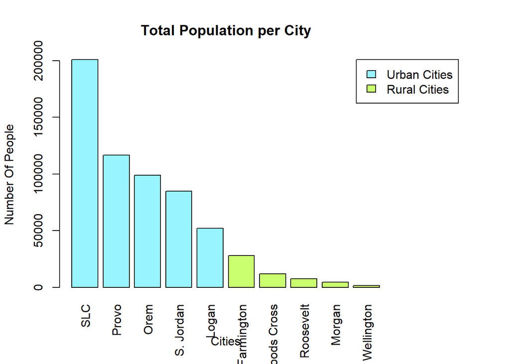

```r
# population plot
totalPopulations <- c(slc_data$population[1], provo_data$population[1], orem_data$population[1], sj_data$population[1],
                      logan_data$population[1], farmington_data$population[1], woodscross_data$population[1], roosevelt_data$population[1],
                      morgan_data$population[1], wellington_data$population[1])
par(mar = c(5.1, 4.1, 4.1, 8.1), xpd=TRUE) # add extra space outside of plot
barplot(totalPopulations,
        names.arg = c("SLC", "Provo", "Orem", "S. Jordan", "Logan", "Farmington", "Woods Cross", "Roosevelt", "Morgan", "Wellington"),
        xlab = "Cities",
        ylab = "Number Of People",
        main = "Total Population per City",
        col=c("cadetblue1", "cadetblue1", "cadetblue1", "cadetblue1", "cadetblue1",  "darkolivegreen1", "darkolivegreen1", "darkolivegreen1", "darkolivegreen1", "darkolivegreen1"), las = 3)
legend("topright", inset=c(-0.2,0),        # add legend to bar plot
       legend = c("Urban Cities", "Rural Cities"),
       fill = c("cadetblue1", "darkolivegreen1"))
```

Next, we created a similar plot for the median household income variable:

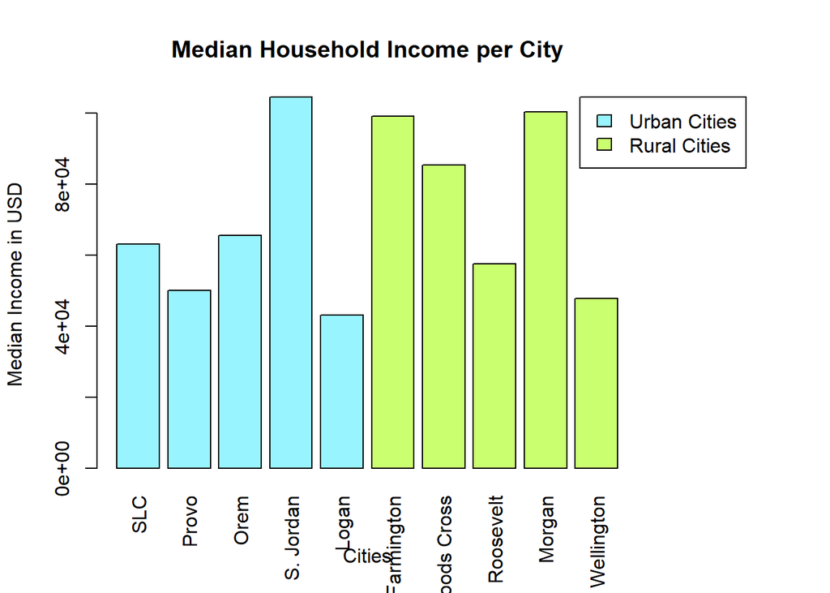

```r
# median income plot
totalMedianIncome <- c(slc_data$median.household.income[1], provo_data$median.household.income[1],
                       orem_data$median.household.income[1], sj_data$median.household.income[1], logan_data$median.household.income[1],
                       farmington_data$median.household.income[1], woodscross_data$median.household.income[1], roosevelt_data$median.household.income[1],
                       morgan_data$median.household.income[1], wellington_data$median.household.income[1])
par(mar = c(5.1, 4.1, 4.1, 8.1), xpd=TRUE) # add extra space outside of plot
barplot(totalMedianIncome,
        names.arg = c("SLC", "Provo", "Orem", "S. Jordan", "Logan", "Farmington", "Woods Cross", "Roosevelt", "Morgan", "Wellington"),
        xlab = "Cities",
        ylab = "Median Income in USD",
        main = "Median Household Income per City",
        col = c("cadetblue1", "cadetblue1", "cadetblue1", "cadetblue1", "cadetblue1",  "darkolivegreen1", "darkolivegreen1", "darkolivegreen1", "darkolivegreen1", "darkolivegreen1"), las = 3)
legend("topright", inset=c(-0.2,0),        # add legend to bar plot
       legend = c("Urban Cities", "Rural Cities"),
       fill = c("cadetblue1", "darkolivegreen1"))
```

Here, we can see much more “uniform” distribution of the median household income variable. One might expect that cities classified as rural would have a much lower median household income than cities classified as urban. However, according to the bar plot of our data, this is not the case. We can see much higher values of median household income in some rural cities compared to large urban ones- such as Farmington versus SLC. One reason this could be is because there are a lot of neighboring cities to Salt Lake City. People could be living in one city but commuting to another for work- however, the median household income variable does not take such factors into account. It is important to note that poverty rates may also affect this statistic; cities with higher populations may have a greater number of people that are below the poverty line. This would bring down the total median income of that city, and this statistic and this study does not take poverty rates into account.

Looking into median household income can provide further insight into store accessibility. If cities on average are making much less than other cities, we can infer that the residents likely have fewer access to transportation resources. This also influences more convenience stores and less supermarket and grocery stores for that area. Median Household income is a possible variable that contributes to store accessibility and store types inherently affecting food deserts.

# Distance Between Stores

As the definition of a food desert explains the distance between grocery stores in a certain area, the next step was to calculate the average distance between stores. This was completed through use of the Geosphere R package (https://cran.r-project.org/web/packages/geosphere/vignettes/geosphere.pdf) as it contains methods to calculate the distance between two latitude-longitude points. The average distance was calculated with the following arithmetic:

```r
# calculating average store distance for each city from longitude and latitude
# initialize distance arrays
slcdist <- replicate(10,0)
logandist <- replicate(10,0)
provodist <- replicate(10,0)
oremdist <- replicate(10,0)
sjdist <- replicate(10,0)
farmingtondist <- replicate(10,0)
morgandist <- replicate(10,0)
wellingtondist <- replicate(10,0)
rooseveltdist <- replicate(10,0)
woodscrossdist <- replicate(10,0)

# loop through and calculate distances between all store variations
i = 0 # which index in distance arrays to change
for (x in 1:5) { # for each store
  nextStore = x + 1 # get index of the store to compare to
  if (nextStore == 6)
    next
  for (y in nextStore:5) { # calculate distance between other stores (that haven't already been calculated)
      i = i + 1 # increment index
      slcdist[i] <- distHaversine(c(slc_data$longitude[x], slc_data$latitude[x]),
                           c(slc_data$longitude[y], slc_data$latitude[y]))
      logandist[i] <- distHaversine(c(logan_data$longitude[x], logan_data$latitude[x]),
                           c(logan_data$longitude[y], logan_data$latitude[y]))
      provodist[i] <- distHaversine(c(provo_data$longitude[x], provo_data$latitude[x]),
                           c(provo_data$longitude[y], provo_data$latitude[y]))
      oremdist[i] <- distHaversine(c(orem_data$longitude[x], orem_data$latitude[x]),
                           c(orem_data$longitude[y], orem_data$latitude[y]))
      sjdist[i] <- distHaversine(c(sj_data$longitude[x], sj_data$latitude[x]),
                           c(sj_data$longitude[y], sj_data$latitude[y]))
      farmingtondist[i] <- distHaversine(c(farmington_data$longitude[x], farmington_data$latitude[x]),
                     c(farmington_data$longitude[y], farmington_data$latitude[y]))
      morgandist[i] <- distHaversine(c(morgan_data$longitude[x], morgan_data$latitude[x]),
                           c(morgan_data$longitude[y], morgan_data$latitude[y]))
      wellingtondist[i] <- distHaversine(c(wellington_data$longitude[x], wellington_data$latitude[x]),
                           c(wellington_data$longitude[y], wellington_data$latitude[y]))
      rooseveltdist[i] <- distHaversine(c(roosevelt_data$longitude[x], roosevelt_data$latitude[x]),
                           c(roosevelt_data$longitude[y], roosevelt_data$latitude[y]))
      woodscrossdist[i] <- distHaversine(c(woodscross_data$longitude[x], woodscross_data$latitude[x]),
                           c(woodscross_data$longitude[y], woodscross_data$latitude[y]))
  }
}
```

To calculate the average distance between each store variation per city (distance between store 1 and 2, distance between store 1 and 3, and so on), we decided to implement a nested for-loop. The outer loop iterates through each store and the inner loop iterates through all stores left to calculate the distance between. By this we mean that if we have already calculated the distance between store 1 and store 2, we do not want to calculate the distance between store 2 and store 1 as that would be a duplicate data point. Inside the inner loop, we calculate the distance between the two current stores with the `distHaversine` function. This function calculates the shortest distance between 2 points- in this case, latitude and longitude points. The function returns the calculated distance in meters. We added each calculated distance per city into distance arrays by city, so that we may access the distances at later points in time and calculate relevant sample statistics. It is important to note that these distances do not account for any road accessibility or distances through roads, but rather uses global coordinates to find closest distance between two stores. Ideally, this study would utilize roads to figure out store distances, but unfortunately, this would be too time-consuming for our study.

To view these calculated distances, we created an array and plot of the means:

[figure not shown]

```r
# store all average distances in a new array
all_avg_distances <- c(mean(slcdist), mean(logandist), mean(provodist), mean(oremdist), mean(sjdist), mean(farmingtondist),
                      mean(woodscrossdist), mean(rooseveltdist), mean(morgandist), mean(wellingtondist))

# distance plot
par(mar = c(5.1, 4.1, 4.1, 8.1), xpd=TRUE) # add extra space outside of plot
barplot(all_avg_distances,
        names.arg = c("SLC", "Provo", "Orem", "S. Jordan", "Logan", "Farmington", "Woods Cross", "Roosevelt", "Morgan", "Wellington"),
        xlab = "Cities",
        ylab = "Distance in Meters (m)",
        main = "Average Distance Between Stores by City",
        col=c("cadetblue1", "cadetblue1", "cadetblue1", "cadetblue1", "cadetblue1",  "darkolivegreen1", "darkolivegreen1", "darkolivegreen1", "darkolivegreen1", "darkolivegreen1"), las = 3)
legend("topright", inset=c(-0.3,0),        # add legend to bar plot
       legend = c("Urban Cities", "Rural Cities"),
       fill = c("cadetblue1", "darkolivegreen1"))
```

As shown in the Average Distance Between Stores In Cities plot above, urban cities appear to have similar average distances whereas the rural cities differ by several thousands in average distances. Furthermore, Farmington and Wellington are well over 6000 meters in average distance while the other rural cities average distance between stores are lower than all the averages calculated in urban areas. One reason for these results may be that rural areas are smaller in area and so therefore the stores in the cities would be more dense. Which is why we can see Morgan, Roosevelt, and Woods cross have lower distance, but there also could rural areas where overall areas are larger than urban cities due to the nature of farming lands or just more land area per house. This could explain why we see a higher average distance between all types of stores for rural areas in Wellington and Farmington. Additionally, Wellington and Farmington are bigger in area than the other rural cities, so we would expect for the grocery stores to be more spaced out.

For additional insight, we calculated the total average distance between stores in urban and rural cities:

```r
# average distance in urban cities
urban_avg_dist <- (mean(slcdist) + mean(logandist) + mean(provodist) + mean(oremdist) + mean(sjdist))/5
urban_avg_dist
```

```
## [1] 3235.745
```

```r
# average distance in rural cities
rural_avg_dist<- (mean(farmingtondist)+ mean(wellingtondist) + mean(morgandist)+ mean(rooseveltdist)+ mean(woodscrossdist))/5
rural_avg_dist
```

```
## [1] 3774.051
```

As calculated, urban average store distances are fewer by 500 meters compared to rural store distances. By looking at store average distances between the others, we can determine how dense the stores are in the area from our sample. This helps us give further insight into store accessibility, and with our data, we can see that urban cities have a more consistent distance, where as rural areas are more variable.

Lastly on the topic of average distance summaries, we created a histogram:

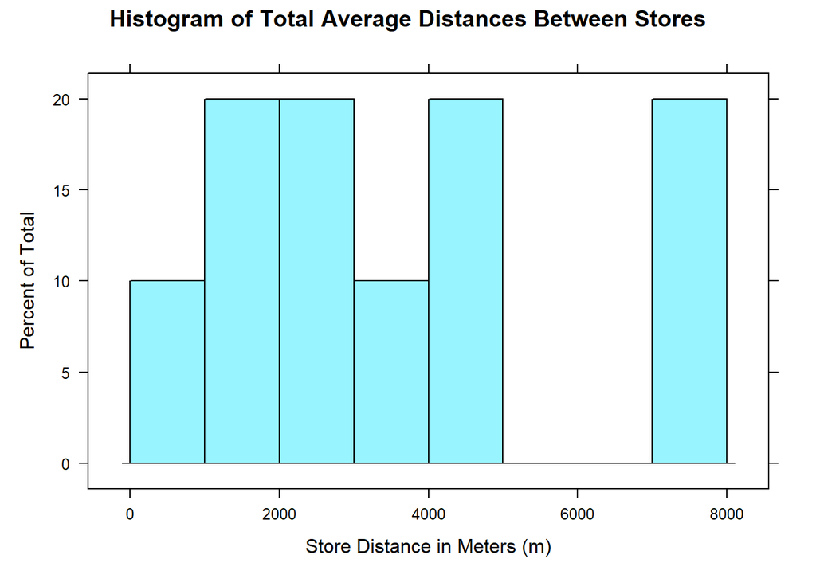

```r
# total average distances histogram - How does store distance behave for all of Utah?
lattice::histogram(all_avg_distances, breaks = 10,
                   main = paste("Histogram of Total Average Distances Between Stores"),
                   xlab = "Store Distance in Meters (m)", col = "cadetblue1")
```

Based on the cumulative histogram, there is a higher frequency of stores that have a distance around 2000-4000 meters. This is above the CDC’s distance definition for food deserts in urban cities. This means that all of the urban cities in our sample may be classified as food deserts. However, none of the distances are above the definition for food deserts in rural cities. So, despite the larger distances between stores compared to urban cities, none of the rural cities in our sample are classified as food deserts. When looking at these results, it is important to note that we calculated the distances between all types of stores including convenience stores, but the definition for food deserts only counts supermarkets/grocery stores and *not* convenience stores. Because of this factor, we decided that it is important and beneficial to look at the distribution of stores types as well for each city.

# Store Type

The final statistic left to examine was store type. We extracted the total number of store types per city from the datasets, combined the store type totals per city into one dataframe and created another bar plot:

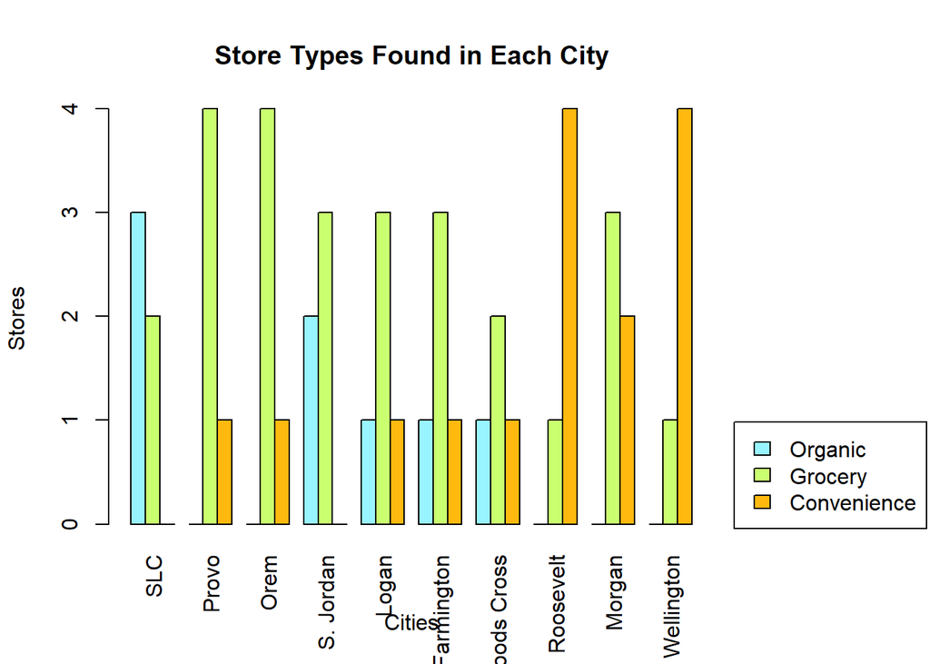

```r
# store total number of store types per city
saltlakecityTotalStoreTypes <- c(length(slc_data[which(slc_data$store.type == 'Organic Grocery Store'),6]),
                                 length(slc_data[which(slc_data$store.type == 'Grocery Store'),6]),
                                 length(slc_data[which(slc_data$store.type == 'Convenience Store'),6]))

provoTotalStoreTypes <- c(length(provo_data[which(provo_data$store.type == 'Organic Grocery Store'),6]),
                          length(provo_data[which(provo_data$store.type == 'Grocery Store'),6]),
                          length(provo_data[which(provo_data$store.type == 'Convenience Store'),6]))

southjordanTotalStoreTypes <- c(length(sj_data[which(sj_data$store.type == 'Organic Grocery Store'),6]),
                                length(sj_data[which(sj_data$store.type == 'Grocery Store'),6]),
                                length(sj_data[which(sj_data$store.type == 'Convenience Store'),6]))

oremTotalStoreTypes <- c(length(orem_data[which(orem_data$store.type == 'Organic Grocery Store'),6]),
                         length(orem_data[which(orem_data$store.type == 'Grocery Store'),6]),
                         length(orem_data[which(orem_data$store.type == 'Convenience Store'),6]))

loganTotalStoreTypes <- c(length(logan_data[which(logan_data$store.type == 'Organic Grocery Store'),6]),
                          length(logan_data[which(logan_data$store.type == 'Grocery Store'),6]),
                          length(logan_data[which(logan_data$store.type == 'Convenience Store'),6]))

wellingtonTotalStoreTypes <- c(length(wellington_data[which(wellington_data$store.type == 'Organic Grocery Store'),6]),
                               length(wellington_data[which(wellington_data$store.type == 'Grocery Store'),6]),
                               length(wellington_data[which(wellington_data$store.type == 'Convenience Store'),6]))

morganTotalStoreTypes <- c(length(morgan_data[which(morgan_data$store.type == 'Organic Grocery Store'),6]),
                           length(morgan_data[which(morgan_data$store.type == 'Grocery Store'),6]),
                           length(morgan_data[which(morgan_data$store.type == 'Convenience Store'),6]))

farmingtonTotalStoreTypes <- c(length(farmington_data[which(farmington_data$store.type == 'Organic Grocery Store'),6]),
                               length(farmington_data[which(farmington_data$store.type == 'Grocery Store'),6]),
                               length(farmington_data[which(farmington_data$store.type == 'Convenience Store'),6]))

rooseveltTotalStoreTypes <- c(length(roosevelt_data[which(roosevelt_data$store.type == 'Organic Grocery Store'),6]),
                              length(roosevelt_data[which(roosevelt_data$store.type == 'Grocery Store'),6]),
                              length(roosevelt_data[which(roosevelt_data$store.type == 'Convenience Store'),6]))

woodscrossTotalStoreTypes <- c(length(woodscross_data[which(woodscross_data$store.type == 'Organic Grocery Store'),6]),
                               length(woodscross_data[which(woodscross_data$store.type == 'Grocery Store'),6]),
                               length(woodscross_data[which(woodscross_data$store.type == 'Convenience Store'),6]))

# combine vectors using c bind function
totalStoreTypes <- cbind(saltlakecityTotalStoreTypes, provoTotalStoreTypes, oremTotalStoreTypes, southjordanTotalStoreTypes,
                         loganTotalStoreTypes, farmingtonTotalStoreTypes, woodscrossTotalStoreTypes, rooseveltTotalStoreTypes,
                         wellingtonTotalStoreTypes, morganTotalStoreTypes)
# plot total store types
par(mar = c(5.1, 4.1, 4.1, 8.1), xpd=TRUE) # add extra space outside of plot
barplot(totalStoreTypes , beside=T,
        names.arg = c("SLC", "Provo", "Orem", "S. Jordan", "Logan", "Farmington", "Woods Cross", "Roosevelt", "Morgan", "Wellington"),
        xlab = "Cities",
        ylab = "Stores",
        main = "Store Types Found in Each City",
        col=c("cadetblue1", "darkolivegreen1", "darkgoldenrod1"), las = 3)
legend("bottomright", inset=c(-0.35,0),        # add legend to bar plot
       legend = c("Organic", "Grocery", "Convenience"),
       fill = c("cadetblue1", "darkolivegreen1", "darkgoldenrod1"))
```

Store types help us look at what is available in the area. By looking to see if a city has more convenience stores or grocery stores, we can get insight into what is mostly accessible in the area. A higher number of convenience stores also contribute to food deserts.

# Distance Confidence Intervals

For more analysis, since we would like “strong evidence” for the bounds of the population parameter, we will approximate a 95% two-sided confidence interval using a t-approximation and the calculated sample mean and sd. We want to know how confident we can actually be that the mean distance between stores that we calculated for our sample are an accurate representation of the true population. The calculated CLT approximations for the mean distance between stores for each city are shown below:

```r
# 95% confidence level - How confident are we that the mean of our sample is an accurate representation of the true population?
t.test(slcdist, conf.level = 0.95)
```

```
##
##  One Sample t-test
##
## data:  slcdist
## t = 4.4304, df = 9, p-value = 0.001646
## alternative hypothesis: true mean is not equal to 0
## 95 percent confidence interval:
##  1426.050 4401.668
## sample estimates:
## mean of x
##  2913.859
```

```r
t.test(provodist, conf.level = 0.95)
```

```
##
##  One Sample t-test
##
## data:  provodist
## t = 4.7634, df = 9, p-value = 0.001025
## alternative hypothesis: true mean is not equal to 0
## 95 percent confidence interval:
##  1632.785 4586.258
## sample estimates:
## mean of x
##  3109.522
```

```r
t.test(oremdist, conf.level = 0.95)
```

```
##
##  One Sample t-test
##
## data:  oremdist
## t = 5.9999, df = 9, p-value = 0.0002025
## alternative hypothesis: true mean is not equal to 0
## 95 percent confidence interval:
##  1276.253 2821.084
## sample estimates:
## mean of x
##  2048.669
```

```r
t.test(sjdist, conf.level = 0.95)
```

```
##
##  One Sample t-test
##
## data:  sjdist
## t = 5.5466, df = 9, p-value = 0.000358
## alternative hypothesis: true mean is not equal to 0
## 95 percent confidence interval:
##  2412.201 5734.968
## sample estimates:
## mean of x
##  4073.585
```

```r
t.test(logandist, conf.level = 0.95)
```

```
##
##  One Sample t-test
##
## data:  logandist
## t = 3.4154, df = 9, p-value = 0.007684
## alternative hypothesis: true mean is not equal to 0
## 95 percent confidence interval:
##  1361.821 6704.358
## sample estimates:
## mean of x
##  4033.089
```

```r
t.test(farmingtondist, conf.level = 0.95)
```

```
##
##  One Sample t-test
##
## data:  farmingtondist
## t = 4.4696, df = 9, p-value = 0.001556
## alternative hypothesis: true mean is not equal to 0
## 95 percent confidence interval:
##   3853.461 11751.529
## sample estimates:
## mean of x
##  7802.495
```

```r
t.test(woodscrossdist, conf.level = 0.95)
```

```
##
##  One Sample t-test
##
## data:  woodscrossdist
## t = 4.4398, df = 9, p-value = 0.001624
## alternative hypothesis: true mean is not equal to 0
## 95 percent confidence interval:
##   965.6316 2971.8503
## sample estimates:
## mean of x
##  1968.741
```

```r
t.test(rooseveltdist, conf.level = 0.95)
```

```
##
##  One Sample t-test
##
## data:  rooseveltdist
## t = 5.1829, df = 9, p-value = 0.0005771
## alternative hypothesis: true mean is not equal to 0
## 95 percent confidence interval:
##   640.5792 1632.8711
## sample estimates:
## mean of x
##  1136.725
```

```r
t.test(morgandist, conf.level = 0.95)
```

```
##
##  One Sample t-test
##
## data:  morgandist
## t = 3.891, df = 9, p-value = 0.003669
## alternative hypothesis: true mean is not equal to 0
## 95 percent confidence interval:
##  171.0834 646.2894
## sample estimates:
## mean of x
##  408.6864
```

```r
t.test(wellingtondist, conf.level = 0.95)
```

```
##
##  One Sample t-test
##
## data:  wellingtondist
## t = 4.4944, df = 9, p-value = 0.001501
## alternative hypothesis: true mean is not equal to 0
## 95 percent confidence interval:
##   3751.674 11355.541
## sample estimates:
## mean of x
##  7553.608
```

For each confidence interval calculated above, we can see the width of the intervals are very wide. A confidence interval indicates where the population parameter is likely to reside. In the case of Salt Lake City, the 95% confidence interval of the mean suggests that we can be 95% confident that the population mean is between 1426.050 meters and 4401.668 meters. This interval has a 2975.618 meter wide gap. Additionally, the borderline distance determining whether or not Salt Lake City is a food desert is 1609 meters- which exists somewhere within this wide range. This seems to be the case for each city’s dataset- the wide interval width mean that we cannot really be that confident that the sample statistics we calculated are representative of the entire population. Meaning, Salt Lake City may actually have a much higher or lower average distance between stores that the limitations of this study caused us to be unable to predict.

In addition to calculating confidence intervals for the mean distance for each city, we also wanted to know how confident we can be in comparing our data. In other words; how confident are we that one city actually has a larger between-store distance than another? The calculated CLT distribution is shown below:

[figure not shown]

```r
# create data frame combining all dist
all_distances <- data.frame(SLC = slcdist, PROVO = provodist, OREM = oremdist, SOUTHJORDAN = sjdist, LOGAN = logandist,
                            FARMINGTON = farmingtondist, WOODSCROSS = woodscrossdist, ROOSEVELT = rooseveltdist,
                            MORGAN = morgandist, WELLINGTON = wellingtondist)

# calculate conf intervals between all cities store distances - How confident are we that one city actually has a larger between-store distance than another?
all_distances_cis <- apply(all_distances, 1, function(x){t.test(x, conf.level = 0.95)})

# check for overlap, data from list
df1 <- read.table(text =
" City  lowerci Estimate    upperci
SLC 392 1912.751    3433
Provo   748 3607.293    6467
Orem    459 3003.557    5548
SouthJordan 1161    3857.936    6555
Logan   1838    4583.664    7392
Farmington  662 3537.668    6413
WoodsCross  834 3067.96 6969
Morgan  591 3263.311    5936
Roosevelt   1830    3844.588    5859
Wellington  1462    4370.249    1285.814
", header = TRUE, as.is = TRUE)

ggplot(df1, aes(x = City, y = Estimate, ymin = lowerci, ymax = upperci)) +
  geom_pointrange() +
  ggtitle("Average Distance Between Stores Confidence Intervals for Each City")
```

Analyzing the plot of the two-sided 95% confidence interval results shows that the interval bounds for several cities overlapped with the bounds of the means for other cities. This overlap of these bounds decreases the “confidence” we can have for the difference in the mean distances between stores being that significant. So, while we may report that one city has a greater average distance between stores than another in our, the data supporting that difference may not actually be that significant to make such a statement about the entire population.

## Conclusions and Discussion

As classified by our rural and urban definitions, there were 5 urban cities and 5 rural cities used for each variable plotting. When we first looked at median household income, there was slight higher overall median household income in the rural cities over urban cities. As we mentioned before, a lot of this data can be coming from commuters who work in a different city than they reside in, but there are also higher poverty levels in urban cities opposed to rural. Overall, it was interesting to see no immediate distinction between urban and rural median household income. Both population and median household income were variables used to analyze the city’s characteristics, but to look at the store’s characteristics, the average store distance and store types from our sample. The average store distance gave insight that rural areas are a lot more variable, since these rural areas can be either large by area or small towns. Subsequently, it made cities like Woods Cross, Roosevelt, and Morgan to have small average distance between our sampled stores, while Farmington and Wellington had high average distance. Average store distance in urban cities are more consistent. It would help to get more store data to make this more representative of the stores in each city making the average distances more accurate. Finally, the store types provides information that rural cities have a much higher number of convenience stores while urban cities have overall more organic and regular grocery stores. This also plays a role into small average store distances in rural areas that are mostly convenience stores inferring that convenience stores are denser in these cities.

We believe that our poor confidence interval results may be due to several possible limiting factors. Firstly, our study greatly suffered due to a lack of data. Collecting data on only 5 stores per city may not be enough to be considered an accurate representative sample. We chose 5 stores because it was nearly impossible to find more than that number for some rural cities- this is also a limiting factor. In rural areas, it is a lot harder to collect which stores are available, especially what types of stores they are. Not all grocery stores, especially smaller local stores, show up on Google Maps. So, using Google Maps to collect store data may not be the best possible tool. If we had more store data, we could have looked at the average distance between different store types (average distance between “Grocery Stores”). As the definition of a food desert looks at supermarkets and not convenience stores, as grocery stores provide the provide the types of food determined as healthy by the CDC- and we saw many more convenience stores in rural areas. Additionally, we calculated distance using average distance between latitude and longitude points, which does not always accurately correlate to the actual distance needed to travel between stores by roads. For further research on this topic, it would be better to find some way to calculate the average shortest distance by road, or to somehow collect that data from a website like Google Maps instead.

In retrospect, our study was also quite broad in scope. We aimed to explore a large area with a limited amount of time and resources to collect data. It may have been better to focus on smaller areas like neighborhoods in a specific Utah city rather than the whole state. However, this approach may also be difficult to collect data for. Some data is only accessible for the whole state while other data is only accessible for the city. For example, we originally wished to also consider vehicle registration data in our study, however, that data was only publicly available by country and not by city. So, there needs to be a good balance between what data is actually collectible.

For further questions on the topic of food deserts in Utah, it would be interesting to consider other variables as factors in what may determine a food desert. For example, it could be possible to create correlation scatter plots between median income, vehicle ownership, and store distance to help determine their correlation and whether they may possibly effect whether or not an area is a food desert. We could also look at other variables like race/ethnicity, population below poverty line as those may also have an effect on food deserts. It would also be possible to frame this question in the context of food-health related diseases like obesity, heart disease, malnourishment, and more. By looking at the incidence rates of this data it would help give more evidence of whether an area actually is a food desert, as they are the direct results of being in one.